# Algorithmes à connaître

```python
from math import *
import matplotlib.pyplot as plt
import numpy as np
```

### Recherche dichotomique

[figure not shown]

##### Dichotomie : recherche d'un élément dans une liste.

Complexité en O(log(n)).  
Non récusif (plus efficace que le récussif ici)

```python
def dichotomie(L,x):
    a,b=0,len(L)
    while b-a>0:
        m=(a+b)//2
        if x>L[m]:
            a=m+1
        elif x<L[m]:
            b=m-1
        else:
            return(True,m)
    return(False)
```

```python
L=[0,1,2,3,5,6,7,8,4]
```

```python
dichotomie(L,6)
```

```
(True, 5)
```

```python
dichotomie(L,56)
```

```
False
```

##### Dichotomie : recherche zéro d'une fonction

Recherche d'un zéro de f sur l'intervalle [a,b]

Complexité en O(log(n)), convergence (quasi) linéaire.

[figure not shown]

```python
def dichotomie_fonction(f,a,b,epsilon):
    while b-a>epsilon:
        m=(a+b)//2
        if f(a)*f(m)>0:
            a=m
        elif f(a)*f(m)<0:
            b=m
        else:
            return(m)
    return((a+b)/2)
```

```python
from math import log, exp
def f(x):
    return(log(x,exp(1)))
def fp(x):
    return(1/x)
```

```python
dichotomie_fonction(f,0.1,5,0.1)
```

```
1.0
```

### Méthode de Newton

Complexité en O(log(n)), convergence quadratique.

f de classe C1 et fp != 0

[figure not shown]

```python
def newton(f,fp,x0,epsilon):
    while abs(f(x0))>epsilon: #suffisament proche de 0
        if abs(fp(x0))<1e-10: #pente trop faible = convergence très lente, division par 0...
            break
        else:
            x0=x0-f(x0)/fp(x0)
    return(x0)
```

```python
newton(f,fp,2,0.00001)
```

```
0.9999925084748383
```

### Algorithmes de tri

##### Tri par insertion

Complexité en O(n2) dans le pire des cas.  
Complexité en O(n) dans le meilleur des cas (liste dejà triée ou presque)

```python
I=[6,5,3,1,8,7,2,4]
```

[figure not shown]

```python
#Insérer L[j] dans L[0,j] dejà triée par ordre croissant.
def inserer(L,j):
    k=j
    while k>0 and L[k]<L[k-1]:
        L[k],L[k-1]=L[k-1],L[k]
        k-=1
    return(L)
```

```python
def tri_insertion(L):
    for k in range(len(L)):
        inserer(L,k)
    return(L)
```

```python
tri_insertion(I)
```

```
[1, 2, 3, 4, 5, 6, 7, 8]
```

##### Tri fusion

```python
T=[38,27,43,3,9,82,10]
```

Complexité en O(nlog(n)) dans le pire des cas.

[figure not shown]

```python
def fusion(L1,L2):
    i1,i2=0,0
    L=[]

    for _ in range(len(L1)+len(L2)):
        if i1==len(L1):
            L.append(L2[i2])
            i2+=1
        elif i2==len(L2):
            L.append(L1[i1])
            i1+=1
        elif L1[i1]<L2[i2]:
            L.append(L1[i1])
            i1+=1
        else:
            L.append(L2[i2])
            i2+=1
    return(L)
```

```python
def tri_fusion(L):
    if len(L)<=1:
        return(L)
    else:
        m=len(L)//2
        return(fusion(tri_fusion(L[:m]),tri_fusion(L[m:])))
```

```python
tri_fusion(T)
```

```
[3, 9, 10, 27, 38, 43, 82]
```

##### Tri rapide

Complexité en 0(n2) dans le pire des cas (qui ne se produit pas en pratique).  
Expérimentalement c'est le tri le plus rapide.

```python
R=[6,5,3,1,8,7,2,4]
```

[figure not shown]

```python
def tri_rapide(L):
    if len(L)<=1:
        return(L)
    else:
        pivot=L[len(L)//2]
        superieurs=[]
        inferieurs=[]
        egaux=[]

        for x in L:
            if x>pivot:
                superieurs.append(x)
            elif x<pivot:
                inferieurs.append(x)
            else:
                egaux.append(x)
    return(tri_rapide(inferieurs)+egaux+tri_rapide(superieurs))
```

```python
tri_rapide(R)
```

```
[1, 2, 3, 4, 5, 6, 7, 8]
```

### Méthode d'Euler (résolution d'équations différentielles)

##### Euler explicite (classique)

###### Ordre 1

[figure not shown]

```python
#Fonction = équation différentielle à résoudre.
def F(y,t):
    return(y) #y'(t)=y(t)

#Liste des instants.
Tps=np.arange(0,10,0.1)
```

```python
#Retourne une approximation de la solution y de l’ED y’=F(y,t) avec la condition initiale y(0) = y0

def euler(F,y0,Tps):
    y=[y0 for _ in range(len(Tps))]

    for i in range(len(Tps)-1):
        y[i+1]=y[i]+(Tps[i+1]-Tps[i])*F(y[i],Tps[i]) # Taylor ordre 1
    return(y)
```

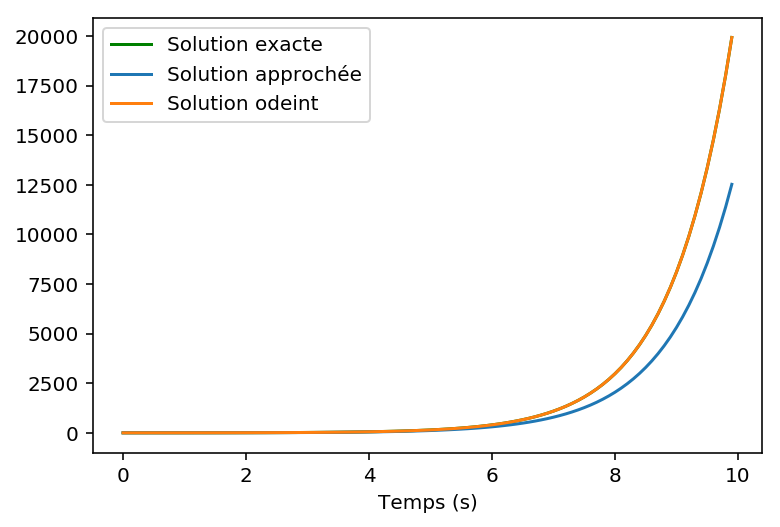

```python
#Affichage de la solution obtenue.
Y=euler(F,1,Tps)

from scipy.integrate import odeint
Z=odeint(F,1,Tps)

#Rappel : plt.subplot(2,1,2) --> 2 lignes, 1 colonne, position 2

plt.plot(Tps,[exp(t) for t in Tps],label="Solution exacte",color="green")
plt.plot(Tps,Y,label="Solution approchée")
plt.plot(Tps,Z,label="Solution odeint")
plt.xlabel("Temps (s)")
plt.legend()

plt.show()
```

Effets de la méthode d'Euler :  
La méthode d'Euler est simple mais l'erreur induite peut être assez élevée si le pas (dt) est choisi trop grand.

###### Ordre 2 : oscillateur harmonique amorti (pendule simple avec frottements)

[figure not shown]

```python
def F(theta,dtheta):
    return(-(g/L)*sin(theta)-(h/m)*dtheta)
```

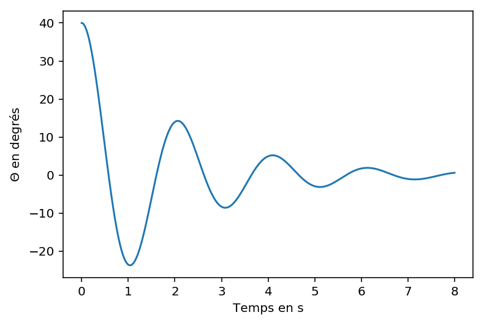

```python
#Conditions initales
theta_ini=40*pi/180 #en rad
dtheta_ini=0

#Paramètres
g=9.81
m=1 #Kg
L=1 #m
h=1 #N.s/m

#Liste des instants (début,fin exclue,pas)
Tps=np.arange(0,8,0.001)

#Euler ordre 2
def euler(F,theta_ini,dtheta_ini,Tps):
    theta=[theta_ini for i in range(len(Tps))]
    dtheta=[dtheta_ini for i in range(len(Tps))]

    for i in range(len(Tps)-1):
        dtheta[i+1]=dtheta[i]+(Tps[i+1]-Tps[i])*F(theta[i],dtheta[i])
        theta[i+1]=theta[i]+(Tps[i+1]-Tps[i])*dtheta[i]
    return(theta)

#Multiplier tous les éléments d'une liste facilement en passant par un tableau numpy.
Theta=np.array(euler(F,theta_ini,dtheta_ini,Tps))*180/pi

plt.plot(Tps,Theta)
plt.xlabel('Temps en s')
plt.ylabel('$\Theta$ en degrés')
plt.show()
```

###### Ordre 2 vectorielle : oscillateur harmonique

[figure not shown]

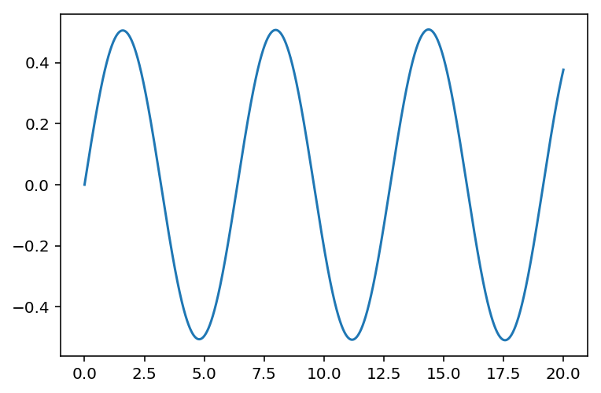

```python
#Liste des instants (début,fin exclue,pas)
Tps=np.arange(0,20,0.001)

#Renvoie array([thetap, thetapp]) car thetapp=-sin(theta)
def F_vect(Y,t):
    theta,thetap=Y
    return(np.array([thetap,-sin(theta)]))

def euler_vectoriel(F_vect,theta_ini,thetap_ini,Tps):
    Y=np.zeros([len(Tps),2])
    Y[:,0][0]=theta_ini
    Y[:,1][0]=thetap_ini

    for i in range(len(Tps)-1):
        Y[i+1]=Y[i]+(Tps[i+1]-Tps[i])*F_vect(Y[i],Tps[i]) # Taylor ordre 1
    return(Y)

sol=euler_vectoriel(F_vect,0,0.5,Tps)

Theta=sol[:,0]
Thetap=sol[:,1]


plt.plot(Tps,Theta)
plt.show()
```

###### Ordre 2 avec odeint : oscillateur harmonique

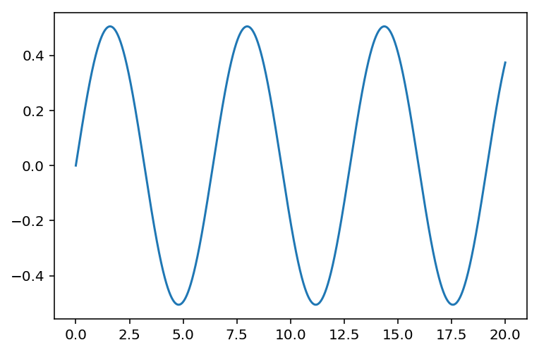

```python
from scipy.integrate import odeint

def F(Y,t):
    theta,thetap = Y
    return np.array([thetap, - np.sin(theta)])

# np.linspace(début,fin,taille)
Tps=np.arange(0,20,0.001)

sol = odeint(F, [0, 0.5], Tps)
Theta , Thetap = sol[:, 0], sol[ :, 1]
plt.plot(Tps, Theta)
plt.show()
```

### Intégration numérique

###### Limites de l'intégration numérique :

La méthode des trapèzes est plus précise que la méthode des rectangles mais toutes les deux ne fournissent qu'une approximation de l'intégrale.  
L'intégration numérique provoque une ''dérive'' (drif) dans le temps qui est d'autant plus grande que le bruit de mesure est grand: il faut filtrer les mesures.

##### Méthode des rectangles.

[figure not shown]

```python
# Yp : liste des valeurs prises par la fontion à intégrer.
# Tps : liste des instants.
def integrale_rectangle(Yp,Tps):
    Y=[0.]*len(Yp)
    for k in range(len(Yp)-1):
        Y[k+1]=Y[k]+(Tps[k+1]-Tps[k])*Yp[k]
    return(Y)
```

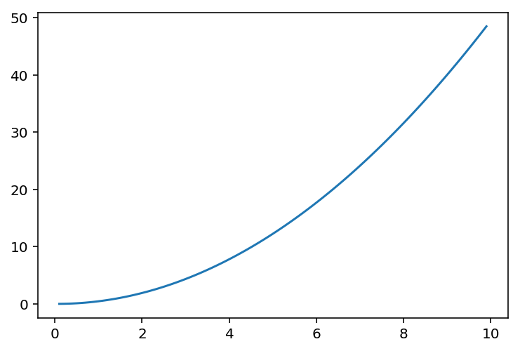

```python
#Integrale de la fonction f(x)=x --> x**2/2
Tps=np.arange(0.1,10,0.1)
Yp=[x for x in Tps]

plt.plot(Tps,integrale_rectangle(Yp,Tps))
plt.show()
```

##### Méthode des trapèzes.

[figure not shown]

```python
# Yp : liste des valeurs prises par la fontion à intégrer.
# Tps : liste des instants.
def integrale_trapezes(Yp,Tps):
    Y=[0.]*len(Yp)
    for k in range(len(Yp)-1):
        Y[k+1]=Y[k]+(Tps[k+1]-Tps[k])*(Yp[k]+Yp[k+1])/2
    return(Y)
```

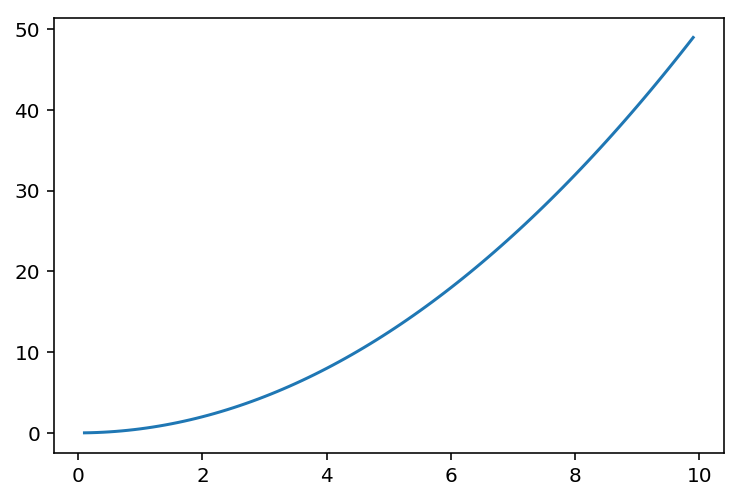

```python
#Integrale de la fonction f(x)=x --> x**2/2
Tps=np.arange(0.1,10,0.1)
Yp=[x for x in Tps]

plt.plot(Tps,integrale_trapezes(Yp,Tps))
plt.show()
```

### Dérivation numérique

###### Limites de la dérivation numérique :

Les méthodes de dérivation numérique classiques provoquent des effets de bords : au début et à la fin du calcul les valeurs de la dérivée ne sont pas réalistes.  
La dérivation numérique amplifie les bruits de mesure, il faut donc avoir un signal filtré (ou lissé) pour obtenir des valeurs de dérivée réalistes.

```python
def derivee_centree(Y,Tps):
    Yp=[0.]*len(Y)
    for k in range(1,len(Y)-1):
        Yp[k]=(Y[k+1]-Y[k-1])/(Tps[k+1]-Tps[k-1])
    return(Yp)

#Remarque : dérivée vers l'arrière (classique) : Yp[k]=(Y[k+1]-Y[k])/(Tps[k+1]-Tps[k])
```

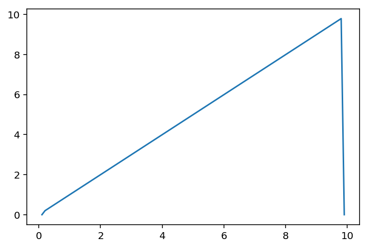

```python
#Dérivée de la fonction f(x)=x**2/2 --> x
Tps=np.arange(0.1,10,0.1)
Yp=[x**2/2 for x in Tps]

plt.plot(Tps,derivee_centree(Yp,Tps))
plt.show() #On voit bien les effets de bords
```

### Divers

##### Binaire récursif :

```python
def binaire_r(n):
    if n==0:
        return([n])
    else:
        return(binaire_r(n//2)+[n%2])
```

```python
print(binaire_r(115))
```

```
[0, 1, 1, 1, 0, 0, 1, 1]
```

##### Inversion de matrices : méthode de Gauss-Jordan.

Complexité cubique O(n3).

[figure not shown]

```python
I=np.identity(np.shape(M)[0])


#Fonction finale pivot de gauss avec recherhe d'un pivot non nul
def pivot_gauss(M):
    n=np.shape(M)[0]

    choix_pivot(M) #Option : recherche de pivot non nul

    #Descente
    for k in range(n):
        #Pivot = 1
        I[k,:]=I[k,:]/M[k,k]
        M[k,:]=M[k,:]/M[k,k]

        for i in range(k+1,n):
            # que des 0 en dessous du pivot
            I[i,:]=I[i,:]-I[k,:]*M[i,k]
            M[i,:]=M[i,:]-M[k,:]*M[i,k]

    #Remontée
    for k in range(n-1,0,-1):
        for i in range(k-1,-1,-1): #erreur dans le QCM : jusqu'à 0 exclu
            I[i,:]=I[i,:]-I[k,:]*M[i,k]
            M[i,:]=M[i,:]-M[k,:]*M[i,k]
    return(I)


##Option : recherche de pivot non nul

#Echanger les lignes Li et Lj
def echange(M,i,j):
    L=M[j,:].copy()
    M[j,:]=M[i,:]
    M[i,:]=L

#Recherche d'un pivot non nul (colonne Cj) sur les lignes en dessous de Lj
def recherche_pivot(M,j):
    nbre_lignes=np.shape(M)[0]
    for i in range(j,nbre_lignes):
        if M[i,j]!=0:
            return(i)

#Choix d'un pivot non nul
def choix_pivot(M):
    nbre_col=np.shape(M)[1]
    for k in range(nbre_col-1):
        if M[k,k]==0:
            i_ligne_pivot=recherche_pivot(M,k)
            echange(I,k,i_ligne_pivot)
            echange(M,k,i_ligne_pivot)
```

```python
#M une matrice carrée avec au moins un flottant!!

M=np.matrix([[2.,6,4],[3,6,9],[2,4,8]])
#M=np.matrix([[0.,6,4],[3,0,9],[2,4,0]])

pivot_gauss(M)
```

```
array([[-1.        ,  2.66666667, -2.5       ],
       [ 0.5       , -0.66666667,  0.5       ],
       [ 0.        , -0.33333333,  0.5       ]])
```